# Data

# Data

- Data types
- From vectors to matrices and lists

# Data types

- logical
- integer
- double
- character

# What is it?

```r
x <- 6
y <- 6L
z <- TRUE
typeof(x)
```

```
## [1] "double"
```

```r
typeof(y)
```

```
## [1] "integer"
```

```r
typeof(z)
```

```
## [1] "logical"
```

```r
is.logical(x)
```

```
## [1] FALSE
```

```r
is.double(x)
```

```
## [1] TRUE
```

# Data conversion

Most conversion is implicit. For explicit conversion, use the `as.*` functions.

Implicit conversion alters everything to the most complex form of data present as follows:

logical -> integer -> double -> character

Explicit conversion usually implies truncation and loss of information.

```r
# Implicit conversion
w <- TRUE
x <- 4L
y <- 5.8
z <- w + x + y
typeof(z)
```

```
## [1] "double"
```

```r
# Explicit conversion. Note loss of data.
as.integer(z)
```

```
## [1] 10
```

# Class

A class is an extension of the basic data types. We’ll see many examples of these. The class of a basic type will be equal to its type apart from ‘double’, whose class is ‘numeric’ for reasons I don’t pretend to understand.

```r
class(TRUE)
```

```
## [1] "logical"
```

```r
class(pi)
```

```
## [1] "numeric"
```

```r
class(4L)
```

```
## [1] "integer"
```

The type and class of a vector is returned as a scalar. Remember a vector is a set of elements which all have the same type.

```r
class(1:4)
```

```
## [1] "integer"
```

# Mode

There is also a function called ‘mode’ which looks tempting. Ignore it.

# Dates and times

Dates in R can be tricky. Two basic classes: `Date` and `POSIXt`. The `Date` class does not get more granular than days. The `POSIXt` class can handle seconds, milliseconds, etc.

My recommendation is to stick with the “Date” class. Introducing times means introducing time zones and possibility for confusion or error. Actuaries rarely need to measure things in minutes.

```r
x <- as.Date('2010-01-01')
class(x)
```

```
## [1] "Date"
```

```r
typeof(x)
```

```
## [1] "double"
```

# More on dates

The default behavior for dates is that they don’t follow US conventions.

Don’t do this:

```r
x <- as.Date('06-30-2010')
```

```
## Error in charToDate(x): character string is not in a standard unambiguous format
```

But this is just fine:

```r
x <- as.Date('30-06-2010')
```

If you want to preserve your sanity, stick with year, month, day.

```r
x <- as.Date('2010-06-30')
```

# What day is it?

To get the date and time of the computer, use the either `Sys.Date()` or `Sys.time()`. Note that `Sys.time()` will return both the day AND the time as a POSIXct object.

```r
x <- Sys.Date()
y <- Sys.time()
```

# More reading on dates

Worth reading the documentation about dates. Measuring time periods is a common task for actuaries. It’s easy to make huge mistakes by getting dates wrong.

The `lubridate` package has some nice convenience functions for setting month and day and reasoning about time periods. It also enables you to deal with time zones, leap days and leap seconds. Probably more than you need.

`mondate` was written by an actuary and supports (among other things) handling time periods in terms of months.

- [Date class](https://stat.ethz.ch/R-manual/R-devel/library/base/html/Dates.html)
- [lubridate](http://www.jstatsoft.org/v40/i03/paper)
- [Ripley and Hornik](http://www.r-project.org/doc/Rnews/Rnews_2001-2.pdf)
- [mondate](https://code.google.com/p/mondate/)

# Factors

Another gotcha. Factors were necessary many years ago when data collection and storage were expensive. A factor is a mapping of a character string to an integer. Particularly when importing data, R often wants to convert character values into a factor. You will often want to convert a factor into a string.

```r
myColors <- c("Red", "Blue", "Green", "Red", "Blue", "Red")
myFactor <- factor(myColors)
typeof(myFactor)
```

```
## [1] "integer"
```

```r
class(myFactor)
```

```
## [1] "factor"
```

```r
is.character(myFactor)
```

```
## [1] FALSE
```

```r
is.character(myColors)
```

```
## [1] TRUE
```

# Altering factors

```r
# This probably won't give you what you expect
myOtherFactor <- c(myFactor, "Orange")
myOtherFactor
```

```
## [1] "3"      "1"      "2"      "3"      "1"      "3"      "Orange"
```

```r
# And this will give you an error
myFactor[length(myFactor)+1] <- "Orange"
# Must do things in two steps
myOtherFactor <- factor(c(levels(myFactor), "Orange"))
myOtherFactor[length(myOtherFactor)+1] <- "Orange"
```

# Avoid factors

Now that you know what they are, you can spend the next few months avoiding factors. When R was created, there were compelling reasons to include factors and they still have some utility. More often than not, though, they’re a confusing hindrance.

If characters aren’t behaving the way you expect them to, check the variables with `is.factor`. Convert them with `as.character` and you’ll be back on the road to happiness.

# Questions

- Create a logical, integer, double and character variable.
- Can you create a vector with both logical and character values?
- What happens when you try to add a logical to an integer? An integer to a double?

# Answers

```r
myLogical <- TRUE
myInteger <- 1:4
myDouble <- 3.14
myCharacter <- "Hello!"

y <- myLogical + myInteger
typeof(y)
```

```
## [1] "integer"
```

```r
y <- myInteger + myDouble
typeof(y)
```

```
## [1] "double"
```

# From vectors to matrices and lists

A matrix is a vector with higher dimensions.

A list has both higher dimensions, but also different data types.

# A matrix

Two ways to construct:

1. Use the `matrix` function.
2. Change the dimensions of a `vector`.

```r
myVector <- 1:100
myMatrix <- matrix(myVector, nrow=10, ncol=10)

myOtherMatrix <- myVector
dim(myOtherMatrix) <- c(10,10)

identical(myMatrix, myOtherMatrix)
```

```
## [1] TRUE
```

```r
myMatrix <- matrix(nrow=10, ncol=10)
```

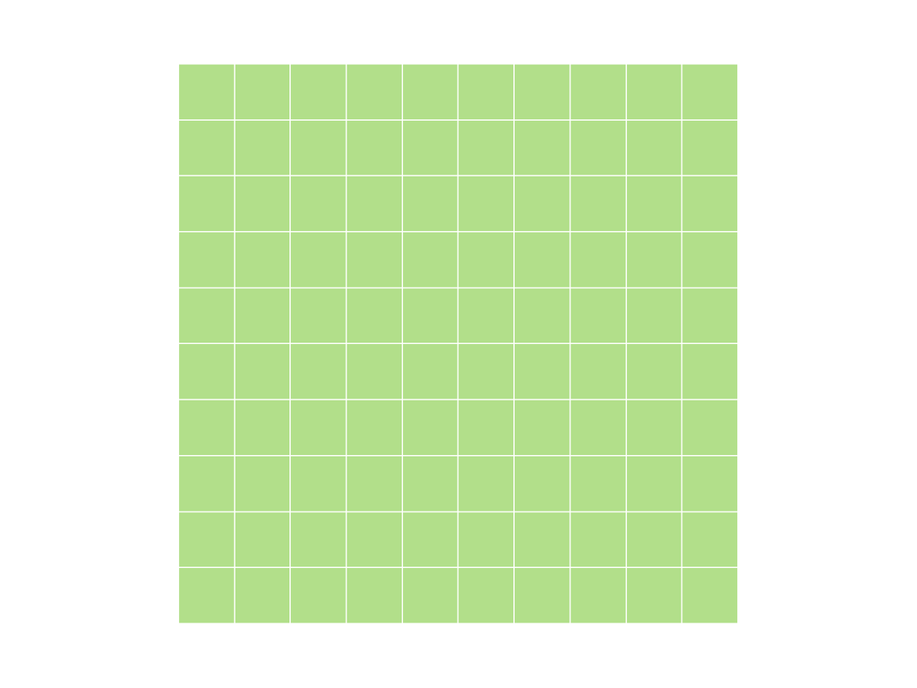

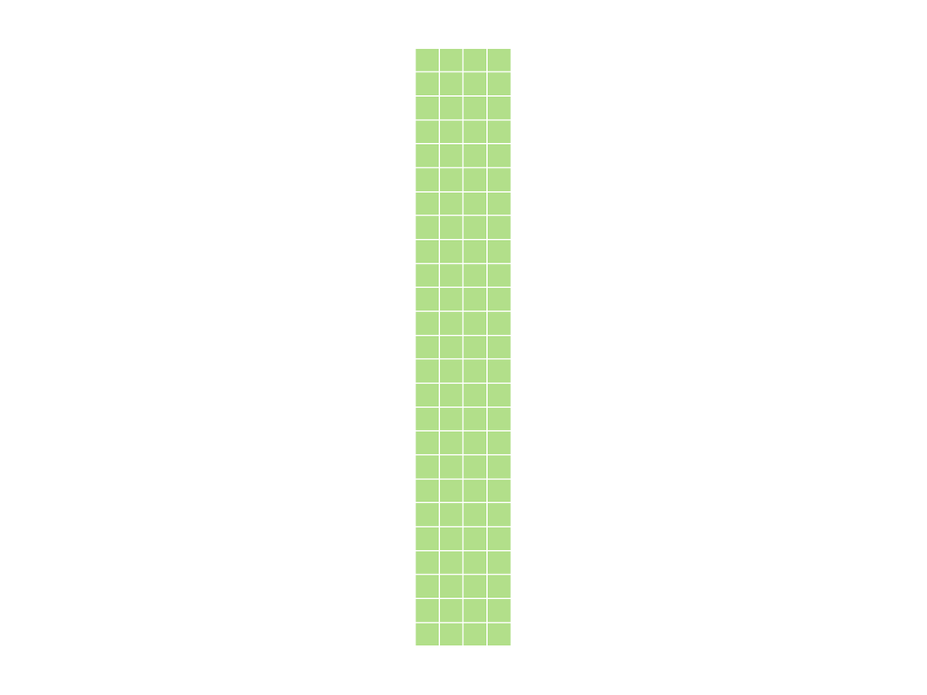

```r
dim(myMatrix) <- c(25, 4)
```

# Matrix metadata

Possible to add metadata. This is typically a name for the columns or rows.

```r
myMatrix <- matrix(nrow=10, ncol=10, data = sample(1:100))
colnames(myMatrix) <- letters[1:10]
head(myMatrix, 3)
```

```
##       a  b  c  d  e  f  g  h  i  j
## [1,] 13 25  9 23 41 99 33 42 40 96
## [2,] 85 79 39 28 17 93 66 26 46 31
## [3,] 29 50 86 56 53 43 68 58 57 54
```

```r
rownames(myMatrix) <- tail(letters, 10)
head(myMatrix, 3)
```

```
##    a  b  c  d  e  f  g  h  i  j
## q 13 25  9 23 41 99 33 42 40 96
## r 85 79 39 28 17 93 66 26 46 31
## s 29 50 86 56 53 43 68 58 57 54
```

# Data access for a matrix

Matrix access is similar to vector, but with additional dimensions. For two-dimensional matrices, the order is row first, then column.

```r
myMatrix[2, ]
```

```
##  a  b  c  d  e  f  g  h  i  j
## 85 79 39 28 17 93 66 26 46 31
```

```r
myMatrix[, 2]
```

```
##  q  r  s  t  u  v  w  x  y  z
## 25 79 50 36 74 49 90 19 67  1
```

# Data access continued

Single index will return values by indexing along only one dimension.

```r
myMatrix[2]
```

```
## [1] 85
```

```r
myMatrix[22]
```

```
## [1] 39
```

# Matrix summary

```r
sum(myMatrix)
```

```
## [1] 5050
```

```r
colSums(myMatrix)
```

```
##   a   b   c   d   e   f   g   h   i   j
## 611 490 372 382 428 669 611 480 427 580
```

```r
rowSums(myMatrix)
```

```
##   q   r   s   t   u   v   w   x   y   z
## 421 510 554 559 673 474 593 414 429 423
```

```r
colMeans(myMatrix)
```

```
##    a    b    c    d    e    f    g    h    i    j
## 61.1 49.0 37.2 38.2 42.8 66.9 61.1 48.0 42.7 58.0
```

# More than two dimensions

Like more than two dimensions? Shine on you crazy diamond.

# Lists

Lists have data of arbitrary complexity. Any type, any length. Note the new `[[ ]]` double bracket operator.

```r
x <- list()
typeof(x)
```

```
## [1] "list"
```

```r
x[[1]] <- c("Hello", "there", "this", "is", "a", "list")
x[[2]] <- c(pi, exp(1))
summary(x)
```

```
##      Length Class  Mode
## [1,] 6      -none- character
## [2,] 2      -none- numeric
```

```r
str(x)
```

```
## List of 2
##  $ : chr [1:6] "Hello" "there" "this" "is" ...
##  $ : num [1:2] 3.14 2.72
```

# Lists

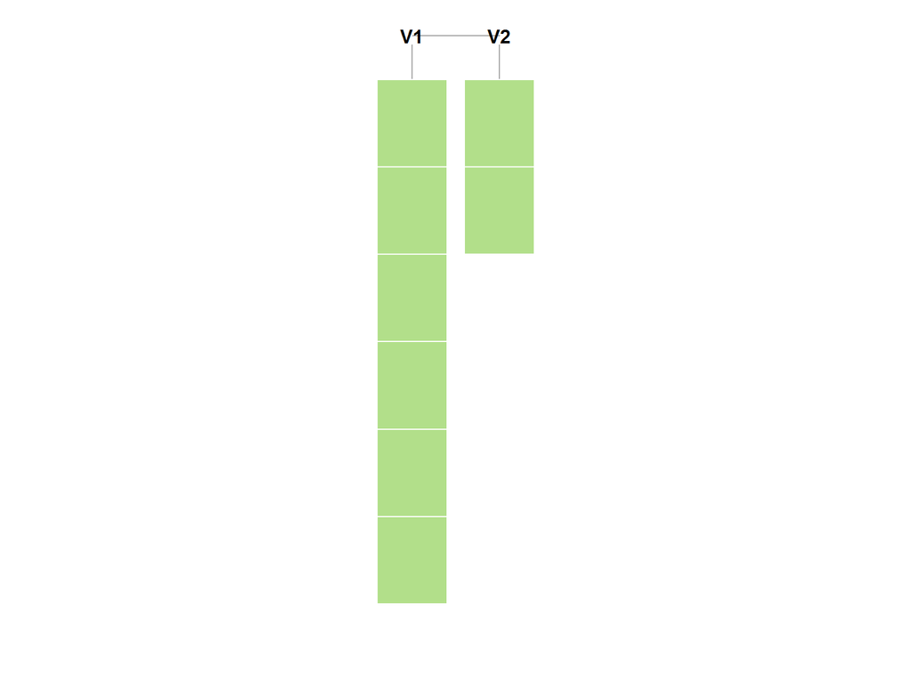

# [ vs. [[

`[` is (almost always) used to set and return an element of the same type as the *containing* object.

`[[` is used to set and return an element of the same type as the *contained* object.

This is why we use `[[` to set an item in a list.

Don’t worry if this doesn’t make sense yet. It’s difficult for most R programmers.

Lists can contain other lists as elements.

```r
y <- list()
y[[1]] <- "Lou Reed"
y[[2]] <- 45

x[[3]] <- y
```

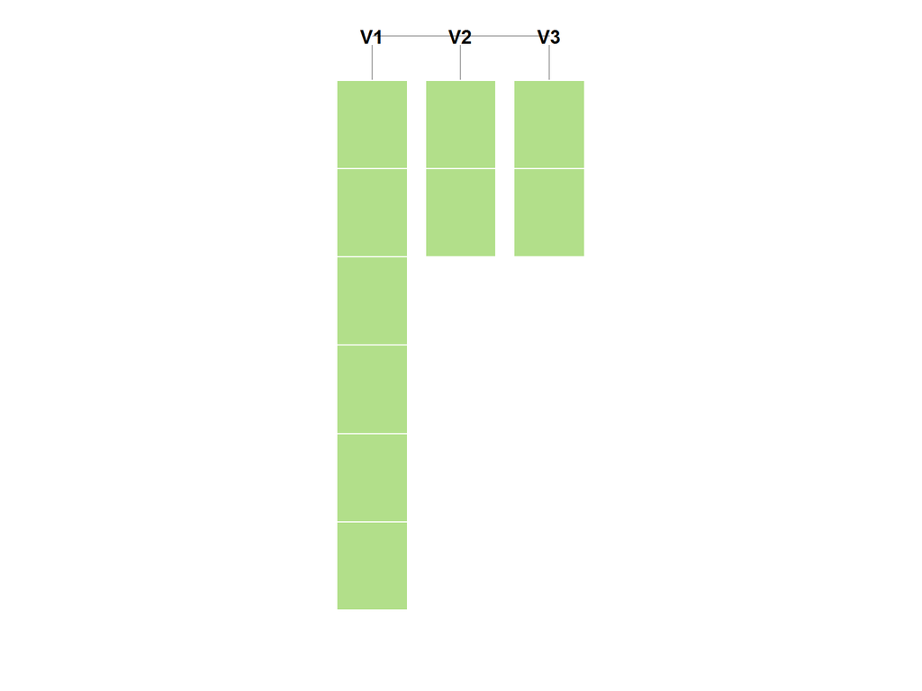

# List metadata

Again, typically names. However, these become very important for lists. Names are handled with the special `$` operator. `$` permits access to a single element. (A single element of a list can be a vector!)

```r
y[[1]] <- c("Lou Reed", "Patti Smith")
y[[2]] <- c(45, 63)

names(y) <- c("Artist", "Age")

y$Artist
```

```
## [1] "Lou Reed"    "Patti Smith"
```

```r
y$Age
```

```
## [1] 45 63
```

# `lapply`

`lapply` is one of many functions which may be applied to lists. Can be difficult at first, but very powerful. Applies the same function to each element of a list

```r
myList <- list(firstVector = c(1:10)
               , secondVector = c(89, 56, 84, 298, 56)
               , thirdVector = c(7,3,5,6,2,4,2))
lapply(myList, mean)
```

```
## $firstVector
## [1] 5.5
##
## $secondVector
## [1] 116.6
##
## $thirdVector
## [1] 4.142857
```

```r
lapply(myList, median)
```

```
## $firstVector
## [1] 5.5
##
## $secondVector
## [1] 84
##
## $thirdVector
## [1] 4
```

```r
lapply(myList, sum)
```

```
## $firstVector
## [1] 55
##
## $secondVector
## [1] 583
##
## $thirdVector
## [1] 29
```

# Summary functions

Because lists are arbitrary, we can’t expect functions like `sum` or `mean` to work. Use `lapply` to summarize particular list elements.

# Questions

- Create a list with two elements. Have the first element be a vector with 100 numbers. Have the second element be a vector with 100 dates. Give your list the names: “Claim” and “Accident Date”.
- What is the average value of the first list element?

# Data frames

All of that was prologue to this. The data frame is a seminal concept in R. Most statistical operations expect one and they are the most common way to pass data in and out of R.

Although critical to understand, this is very, very easy to get. What’s a data frame? It’s a table. That’s it.

A data frame is a `list` of `vectors`. Each `vector` may have a different data type, but all must be the same length.

# Data frames

- Creating
- Referencing
- Ordering
- Adding new columns
- Subsetting
- Summarizing
- Merging

# Creating a data frame

```r
set.seed(1234)
State = rep(c("TX", "NY", "CA"), 10)
EarnedPremium = rlnorm(length(State), meanlog = log(50000), sdlog=1)
EarnedPremium = round(EarnedPremium, -3)
Losses = EarnedPremium * runif(length(EarnedPremium), min=0.4, max = 0.9)

df = data.frame(State, EarnedPremium, Losses, stringsAsFactors=FALSE)
```

# Basic properties of a data frame

```r
summary(df)
```

```
##     State           EarnedPremium        Losses
##  Length:30          Min.   :  5000   Min.   :  2034
##  Class :character   1st Qu.: 21250   1st Qu.: 12461
##  Mode  :character   Median : 30500   Median : 17363
##                     Mean   : 61500   Mean   : 39006
##                     3rd Qu.: 63750   3rd Qu.: 41465
##                     Max.   :560000   Max.   :411179
```

```r
str(df)
```

```
## 'data.frame':    30 obs. of  3 variables:
##  $ State        : chr  "TX" "NY" "CA" "TX" ...
##  $ EarnedPremium: num  15000 66000 148000 5000 77000 83000 28000 29000 28000 21000 ...
##  $ Losses       : num  12486 27781 82671 2034 40002 ...
```

# More basic properties of a data frame

```r
names(df)
```

```
## [1] "State"         "EarnedPremium" "Losses"
```

```r
colnames(df)
```

```
## [1] "State"         "EarnedPremium" "Losses"
```

```r
length(df)
```

```
## [1] 3
```

```r
dim(df)
```

```
## [1] 30  3
```

```r
nrow(df)
```

```
## [1] 30
```

```r
ncol(df)
```

```
## [1] 3
```

# And still more basic properties

```r
head(df)
```

```
##   State EarnedPremium    Losses
## 1    TX         15000 12486.254
## 2    NY         66000 27781.290
## 3    CA        148000 82671.479
## 4    TX          5000  2034.375
## 5    NY         77000 40002.490
## 6    CA         83000 62519.527
```

```r
head(df, 2)
```

```
##   State EarnedPremium   Losses
## 1    TX         15000 12486.25
## 2    NY         66000 27781.29
```

```r
tail(df)
```

```
##    State EarnedPremium    Losses
## 25    TX         25000 12452.183
## 26    NY         12000 10191.483
## 27    CA         89000 52932.740
## 28    TX         18000  9997.837
## 29    NY         49000 23520.702
## 30    CA         20000 16961.858
```

# Referencing

Very similar to referencing a 2D matrix.

```r
df[2,3]
df[2]
df[2,]
df[2, -1]
```

# More referencing

Note the `$` operator to access named columns. A data frame uses the ‘name’ metadata in the same way as a list.

```r
df$EarnedPremium
# Columns of a data frame may be treated as vectors
df$EarnedPremium[3]
df[2:4, 1:2]
df[, "EarnedPremium"]
df[, c("EarnedPremium", "State")]
```

# Ordering

```r
order(df$EarnedPremium)
```

```
##  [1]  4 26  1 12 28 18 30 10 19 13 25  7  9  8 17 11 22 23 16 29 14 21  2
## [24]  5 24  6 27 15  3 20
```

```r
df = df[order(df$EarnedPremium), ]
```

# Altering and adding columns

```r
df$LossRatio = df$EarnedPremium / df$Losses
df$LossRatio = 1 / df$LossRatio
```

# Eliminating columns

```r
df$LossRatio = NULL
df = df[, 1:2]
```

# rbind, cbind

`rbind` will append rows to the data frame. New rows must have the same number of columns and data types. `cbind` must have the same number of rows as the data frame.

```r
dfA = df[1:10,]
dfB = df[11:20, ]
rbind(dfA, dfB)
dfC = dfA[, 1:2]
cbind(dfA, dfC)
```

# Merging

```r
dfRateChange = data.frame(State =c("TX", "CA", "NY"), RateChange = c(.05, -.1, .2))
df = merge(df, dfRateChange)
```

Merging is VLOOKUP on steroids. Basically equivalent to a JOIN in SQL.

# Altering column names

```r
df$LossRation = with(df, Losses / EarnedPremium)
names(df)
```

```
## [1] "State"         "EarnedPremium" "RateChange"    "LossRation"
```

```r
colnames(df)[4] = "Loss Ratio"
colnames(df)
```

```
## [1] "State"         "EarnedPremium" "RateChange"    "Loss Ratio"
```

# Subsetting - The easy way

```r
dfTX = subset(df, State == "TX")
dfBigPolicies = subset(df, EarnedPremium >= 50000)
```

# Subsetting - The hard(ish) way

```r
dfTX = df[df$State == "TX", ]
dfBigPolicies = df[df$EarnedPremium >= 50000, ]
```

# Subsetting - Yet another way

```r
whichState = df$State == "TX"
dfTX = df[whichState, ]

whichEP = df$EarnedPremium >= 50000
dfBigPolicies = df[whichEP, ]
```

# Subsetting

I use each of these three methods routinely. They’re all good.

# Summarizing

```r
sum(df$EarnedPremium)
```

```
## [1] 1845000
```

```r
sum(df$EarnedPremium[df$State == "TX"])
```

```
## [1] 233000
```

```r
aggregate(df[,-1], list(df$State), sum)
```

```
##   Group.1 EarnedPremium RateChange Loss Ratio
## 1      CA        673000       -1.0   8.257125
## 2      NY        939000        2.0  11.755127
## 3      TX        233000        0.5  18.745791
```

# Summarizing visually - 1

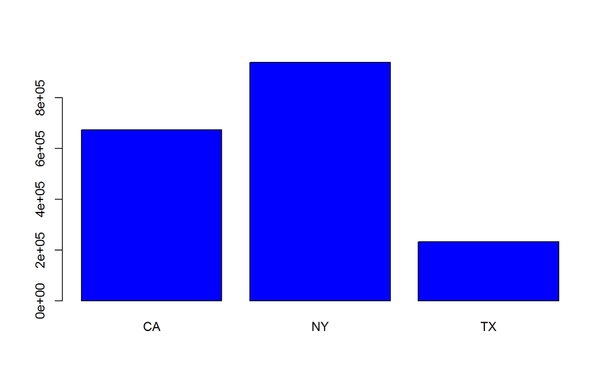

```r
dfByState = aggregate(df$EarnedPremium, list(df$State), sum)
colnames(dfByState) = c("State", "EarnedPremium")
barplot(dfByState$EarnedPremium, names.arg=dfByState$State, col="blue")
```

# Summarizing visually - 2

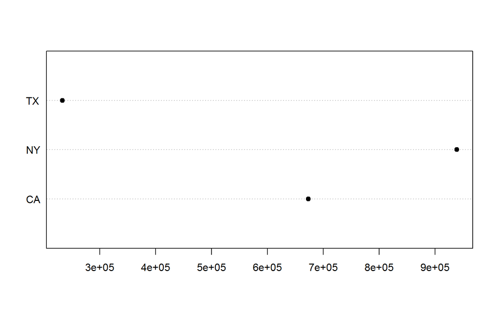

```r
dotchart(dfByState$EarnedPremium, dfByState$State, pch=19)
```

# Advanced data frame tools

- dplyr
- tidyr
- reshape2
- data.table

# Final note on data frames

Roughly 90% of your work in R will involve manipulation of data frames. There are truckloads of packages designed to make manipulation of data frames easier. Take your time getting to learn these tools. They’re all powerful, but they’re all a little different. I’d suggest learning the functions in `base` R first, then moving on to tools like `dplyr` and `data.table`. There’s a lot to be gained from understanding the problems those packages were created to solve.

# Reading data

```r
myData = read.csv("SomeFile.csv")
```

# Reading from Excel

Actually there are several ways: * XLConnect * xlsx * Excelsi-r

```r
library(XLConnect)
wbk = loadWorkbook("myWorkbook.xlsx")
df = readWorksheet(wbk, someSheet)
```

# Reading from the web - 1

```r
URL = "http://www.casact.org/research/reserve_data/ppauto_pos.csv"
df = read.csv(URL, stringsAsFactors = FALSE)
```

# Reading from the web - 2

```r
library(XML)
URL = "http://www.pro-football-reference.com/teams/nyj/2012_games.htm"
games = readHTMLTable(URL, stringsAsFactors = FALSE)
```

# Reading from a database

```r
library(RODBC)
myChannel = odbcConnect(dsn = "MyDSN_Name")
df = sqlQuery(myChannel, "SELECT stuff FROM myTable")
```

# Read some data

```r
df = read.csv("../data/StateData.csv")
```

```r
View(df)
```

# Questions

- Load the data from “StateData.csv” into a data frame.
- Which state has the most premium?